# Lab 11 Activity Key

Author

Published

Invalid Date

### Activity Objectives:

- Repeated Measures ANOVA

### Instructions:

- Fill in the code chunks
- Render the Quarto document and submit both the `.qmd` and `.html` file on Canvas

## Activity

### 1) If you’d like to load packages with `library()`, please do so in this block. Please install and load the `datarium` package. We are going to use the `performance` dataset within the `datarium` package today: use `?datarium::performance` to learn about the data. As a note, this data is simulated.

```r
library(tidyverse)
```

### 2) Read in the data and use a few functions to explore it.

### 3) What variables are in this dataset? Which are within-subjects and which are between-subjects?

### 4) We are interested in the effect of time on performance scores. In order to conduct an ANOVA on the effect of time, the values from `t1` and `t2` need to be in a single `time` column. Pivot the data to do this, and display the first few rows of the data after the transformation!

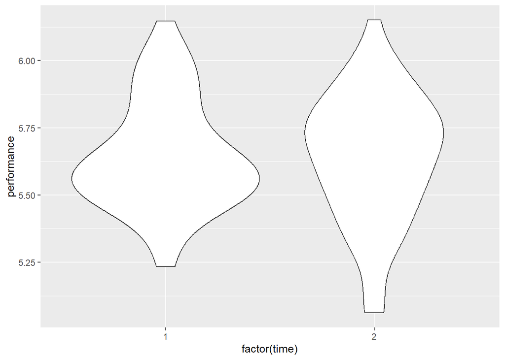

```r
perf <- datarium::performance |>
  pivot_longer(cols = c("t1", "t2"),
               names_to = "time", values_to = "performance") |>
  mutate(id = factor(id))

perf |>
  mutate(time = parse_number(time)) |>
  ggplot(aes(x = factor(time), y = performance)) +
  scale_x_discrete() +
  geom_violin()
```

### 5) Conduct a Repeated Measures ANOVA of the effect of time on performance scores. Display the results.

```r
raov <- afex::aov_ez(
  id = "id",
  dv = "performance",
  data = perf,
  within = "time"
)
summary(raov)
```

```
Univariate Type III Repeated-Measures ANOVA Assuming Sphericity

            Sum Sq num Df Error SS den Df    F value Pr(>F)
(Intercept) 3822.9      1   3.4546     59 65290.5286 <2e-16 ***
time           0.0      1   2.3648     59     0.0499 0.8241
---
Signif. codes:  0 '***' 0.001 '**' 0.01 '*' 0.05 '.' 0.1 ' ' 1
```

### 6) Check assumptions and comment on whether the assumptions seem to hold.

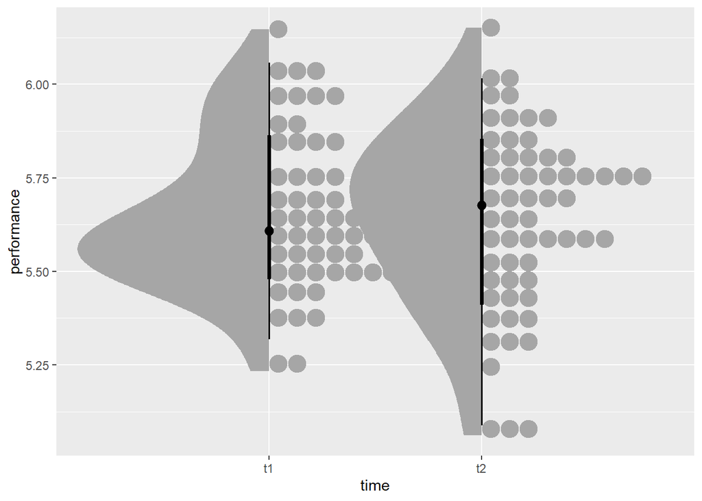

```r
perf |>
  ggplot(aes(x = time, y = performance)) +
  ggdist::geom_dots() +
  ggdist::stat_halfeye(side = "left")
```

### 7) Conduct a Mixed ANOVA of the effect of time and stress on performance scores. Consider whether or not the data is balanced and what type of Sums of Squares would be appropriate.

```r
maov <- afex::aov_ez(
  id = "id",
  dv = "performance",
  data = perf,
  within = "time",
  between = "stress"
)
```

```
Contrasts set to contr.sum for the following variables: stress
```

```r
summary(maov)
```

```
Univariate Type III Repeated-Measures ANOVA Assuming Sphericity

            Sum Sq num Df Error SS den Df    F value    Pr(>F)
(Intercept) 3822.9      1   2.0187     57 1.0794e+05 < 2.2e-16 ***
stress         1.4      2   2.0187     57 2.0272e+01  2.24e-07 ***
time           0.0      1   2.2494     57 5.0600e-02    0.8227
stress:time    0.1      2   2.2494     57 1.4630e+00    0.2401
---
Signif. codes:  0 '***' 0.001 '**' 0.01 '*' 0.05 '.' 0.1 ' ' 1
```

### 8) Check assumptions and comment on whether the assumptions seem to hold.

### 9) Create a visualization showing the results of the model.

### 10) In APA format, discuss the results from the Mixed ANOVA model. Feel free to reference the visualization.

$$(N - G_\text{between}) \times (G_\text{within} - 1)$$
(N - # between groups) * (# within groups - 1)